# Risk Factor Analysis

## Outcome Variable

**Outcome Variable:** ever_wasted

## Predictor Variables

**Intervention Variable:** predfeed6

**Adjustment Set:**

unadjusted

## Stratifying Variables

The analysis was stratified on these variable(s):

- agecat
- studyid
- country

## Data Summary

| agecat | studyid | country | predfeed6 | ever_wasted | n_cell | n |
| --- | --- | --- | --- | --- | --- | --- |
| 0-24 months (no birth wast) | ki0047075b-MAL-ED | BANGLADESH | 0 | 0 | 92 | 238 |
| 0-24 months (no birth wast) | ki0047075b-MAL-ED | BANGLADESH | 0 | 1 | 21 | 238 |
| 0-24 months (no birth wast) | ki0047075b-MAL-ED | BANGLADESH | 1 | 0 | 89 | 238 |
| 0-24 months (no birth wast) | ki0047075b-MAL-ED | BANGLADESH | 1 | 1 | 36 | 238 |
| 0-24 months (no birth wast) | ki0047075b-MAL-ED | BRAZIL | 0 | 0 | 164 | 211 |
| 0-24 months (no birth wast) | ki0047075b-MAL-ED | BRAZIL | 0 | 1 | 12 | 211 |
| 0-24 months (no birth wast) | ki0047075b-MAL-ED | BRAZIL | 1 | 0 | 35 | 211 |
| 0-24 months (no birth wast) | ki0047075b-MAL-ED | BRAZIL | 1 | 1 | 0 | 211 |
| 0-24 months (no birth wast) | ki0047075b-MAL-ED | INDIA | 0 | 0 | 130 | 230 |
| 0-24 months (no birth wast) | ki0047075b-MAL-ED | INDIA | 0 | 1 | 81 | 230 |
| 0-24 months (no birth wast) | ki0047075b-MAL-ED | INDIA | 1 | 0 | 15 | 230 |
| 0-24 months (no birth wast) | ki0047075b-MAL-ED | INDIA | 1 | 1 | 4 | 230 |
| 0-24 months (no birth wast) | ki0047075b-MAL-ED | NEPAL | 0 | 0 | 165 | 235 |
| 0-24 months (no birth wast) | ki0047075b-MAL-ED | NEPAL | 0 | 1 | 41 | 235 |
| 0-24 months (no birth wast) | ki0047075b-MAL-ED | NEPAL | 1 | 0 | 26 | 235 |
| 0-24 months (no birth wast) | ki0047075b-MAL-ED | NEPAL | 1 | 1 | 3 | 235 |
| 0-24 months (no birth wast) | ki0047075b-MAL-ED | PERU | 0 | 0 | 142 | 270 |
| 0-24 months (no birth wast) | ki0047075b-MAL-ED | PERU | 0 | 1 | 14 | 270 |
| 0-24 months (no birth wast) | ki0047075b-MAL-ED | PERU | 1 | 0 | 110 | 270 |
| 0-24 months (no birth wast) | ki0047075b-MAL-ED | PERU | 1 | 1 | 4 | 270 |
| 0-24 months (no birth wast) | ki0047075b-MAL-ED | SOUTH AFRICA | 0 | 0 | 202 | 248 |
| 0-24 months (no birth wast) | ki0047075b-MAL-ED | SOUTH AFRICA | 0 | 1 | 43 | 248 |
| 0-24 months (no birth wast) | ki0047075b-MAL-ED | SOUTH AFRICA | 1 | 0 | 3 | 248 |
| 0-24 months (no birth wast) | ki0047075b-MAL-ED | SOUTH AFRICA | 1 | 1 | 0 | 248 |
| 0-24 months (no birth wast) | ki0047075b-MAL-ED | TANZANIA, UNITED REPUBLIC OF | 0 | 0 | 216 | 248 |
| 0-24 months (no birth wast) | ki0047075b-MAL-ED | TANZANIA, UNITED REPUBLIC OF | 0 | 1 | 30 | 248 |
| 0-24 months (no birth wast) | ki0047075b-MAL-ED | TANZANIA, UNITED REPUBLIC OF | 1 | 0 | 2 | 248 |
| 0-24 months (no birth wast) | ki0047075b-MAL-ED | TANZANIA, UNITED REPUBLIC OF | 1 | 1 | 0 | 248 |
| 0-24 months (no birth wast) | ki1000109-EE | PAKISTAN | 0 | 0 | 166 | 754 |
| 0-24 months (no birth wast) | ki1000109-EE | PAKISTAN | 0 | 1 | 146 | 754 |

[output cut: 126 more lines]

The following strata were considered:

- agecat: 0-24 months (no birth wast), studyid: ki0047075b-MAL-ED, country: BANGLADESH
- agecat: 0-24 months (no birth wast), studyid: ki0047075b-MAL-ED, country: BRAZIL
- agecat: 0-24 months (no birth wast), studyid: ki0047075b-MAL-ED, country: INDIA
- agecat: 0-24 months (no birth wast), studyid: ki0047075b-MAL-ED, country: NEPAL
- agecat: 0-24 months (no birth wast), studyid: ki0047075b-MAL-ED, country: PERU
- agecat: 0-24 months (no birth wast), studyid: ki0047075b-MAL-ED, country: SOUTH AFRICA
- agecat: 0-24 months (no birth wast), studyid: ki0047075b-MAL-ED, country: TANZANIA, UNITED REPUBLIC OF
- agecat: 0-24 months (no birth wast), studyid: ki1000109-EE, country: PAKISTAN
- agecat: 0-24 months (no birth wast), studyid: ki1000304b-SAS-FoodSuppl, country: INDIA
- agecat: 0-24 months (no birth wast), studyid: ki1113344-GMS-Nepal, country: NEPAL
- agecat: 0-24 months (no birth wast), studyid: ki1148112-LCNI-5, country: MALAWI
- agecat: 0-24 months (no birth wast), studyid: kiGH5241-JiVitA-3, country: BANGLADESH
- agecat: 0-24 months (no birth wast), studyid: kiGH5241-JiVitA-4, country: BANGLADESH
- agecat: 0-6 months (no birth wast), studyid: ki0047075b-MAL-ED, country: BANGLADESH
- agecat: 0-6 months (no birth wast), studyid: ki0047075b-MAL-ED, country: BRAZIL
- agecat: 0-6 months (no birth wast), studyid: ki0047075b-MAL-ED, country: INDIA
- agecat: 0-6 months (no birth wast), studyid: ki0047075b-MAL-ED, country: NEPAL
- agecat: 0-6 months (no birth wast), studyid: ki0047075b-MAL-ED, country: PERU
- agecat: 0-6 months (no birth wast), studyid: ki0047075b-MAL-ED, country: SOUTH AFRICA
- agecat: 0-6 months (no birth wast), studyid: ki0047075b-MAL-ED, country: TANZANIA, UNITED REPUBLIC OF
- agecat: 0-6 months (no birth wast), studyid: ki1000109-EE, country: PAKISTAN
- agecat: 0-6 months (no birth wast), studyid: ki1000304b-SAS-FoodSuppl, country: INDIA
- agecat: 0-6 months (no birth wast), studyid: ki1113344-GMS-Nepal, country: NEPAL
- agecat: 0-6 months (no birth wast), studyid: ki1148112-LCNI-5, country: MALAWI
- agecat: 0-6 months (no birth wast), studyid: kiGH5241-JiVitA-3, country: BANGLADESH
- agecat: 0-6 months (no birth wast), studyid: kiGH5241-JiVitA-4, country: BANGLADESH
- agecat: 6-24 months, studyid: ki0047075b-MAL-ED, country: BANGLADESH
- agecat: 6-24 months, studyid: ki0047075b-MAL-ED, country: BRAZIL
- agecat: 6-24 months, studyid: ki0047075b-MAL-ED, country: INDIA
- agecat: 6-24 months, studyid: ki0047075b-MAL-ED, country: NEPAL
- agecat: 6-24 months, studyid: ki0047075b-MAL-ED, country: PERU
- agecat: 6-24 months, studyid: ki0047075b-MAL-ED, country: SOUTH AFRICA
- agecat: 6-24 months, studyid: ki0047075b-MAL-ED, country: TANZANIA, UNITED REPUBLIC OF
- agecat: 6-24 months, studyid: ki1000109-EE, country: PAKISTAN
- agecat: 6-24 months, studyid: ki1000304b-SAS-FoodSuppl, country: INDIA
- agecat: 6-24 months, studyid: ki1113344-GMS-Nepal, country: NEPAL
- agecat: 6-24 months, studyid: ki1148112-LCNI-5, country: MALAWI
- agecat: 6-24 months, studyid: kiGH5241-JiVitA-3, country: BANGLADESH
- agecat: 6-24 months, studyid: kiGH5241-JiVitA-4, country: BANGLADESH

### Dropped Strata

Some strata were dropped due to rare outcomes:

- agecat: 0-24 months (no birth wast), studyid: ki0047075b-MAL-ED, country: BRAZIL
- agecat: 0-24 months (no birth wast), studyid: ki0047075b-MAL-ED, country: INDIA
- agecat: 0-24 months (no birth wast), studyid: ki0047075b-MAL-ED, country: NEPAL
- agecat: 0-24 months (no birth wast), studyid: ki0047075b-MAL-ED, country: PERU
- agecat: 0-24 months (no birth wast), studyid: ki0047075b-MAL-ED, country: SOUTH AFRICA
- agecat: 0-24 months (no birth wast), studyid: ki0047075b-MAL-ED, country: TANZANIA, UNITED REPUBLIC OF
- agecat: 0-24 months (no birth wast), studyid: ki1000304b-SAS-FoodSuppl, country: INDIA
- agecat: 0-6 months (no birth wast), studyid: ki0047075b-MAL-ED, country: BRAZIL
- agecat: 0-6 months (no birth wast), studyid: ki0047075b-MAL-ED, country: INDIA
- agecat: 0-6 months (no birth wast), studyid: ki0047075b-MAL-ED, country: NEPAL
- agecat: 0-6 months (no birth wast), studyid: ki0047075b-MAL-ED, country: PERU
- agecat: 0-6 months (no birth wast), studyid: ki0047075b-MAL-ED, country: SOUTH AFRICA
- agecat: 0-6 months (no birth wast), studyid: ki0047075b-MAL-ED, country: TANZANIA, UNITED REPUBLIC OF
- agecat: 0-6 months (no birth wast), studyid: ki1000304b-SAS-FoodSuppl, country: INDIA
- agecat: 0-6 months (no birth wast), studyid: ki1148112-LCNI-5, country: MALAWI
- agecat: 6-24 months, studyid: ki0047075b-MAL-ED, country: BRAZIL
- agecat: 6-24 months, studyid: ki0047075b-MAL-ED, country: INDIA
- agecat: 6-24 months, studyid: ki0047075b-MAL-ED, country: NEPAL
- agecat: 6-24 months, studyid: ki0047075b-MAL-ED, country: PERU
- agecat: 6-24 months, studyid: ki0047075b-MAL-ED, country: SOUTH AFRICA
- agecat: 6-24 months, studyid: ki0047075b-MAL-ED, country: TANZANIA, UNITED REPUBLIC OF
- agecat: 6-24 months, studyid: ki1000304b-SAS-FoodSuppl, country: INDIA

## Methods Detail

We’re interested in the causal parameters $E[Y_a]$ for all values of $a \in \mathcal{A}$. These parameters represent the mean outcome if, possibly contrary to fact, we intervened to set all units to have $A=a$. Under the randomization and positivity assumptions, these are identified by the statistical parameters $\psi_a=E_W[E_{Y|A,W}(Y|A=a,W)]$. In addition, we’re interested in the mean of $Y$, $E[Y]$ under no intervention (the observed mean). We will estimate these parameters by using SuperLearner to fit the relevant likelihood factors – $E_{Y|A,W}(Y|A=a,W)$ and $p(A=a|W)$, and then updating our likelihood fit using a joint TMLE.

For unadjusted analyses ($W=\{\}$), initial likelihoods were estimated using Lrnr_glm to estimate the simple $E(Y|A)$ and Lrnr_mean to estimate $p(A)$. For adjusted analyses, a small library containing Lrnr_glmnet, Lrnr_xgboost, and Lrnr_mean was used.

Having estimated these parameters, we will then use the delta method to estimate relative risks and attributable risks relative to a prespecified baseline level of $A$.

# Results Detail

## Results Plots

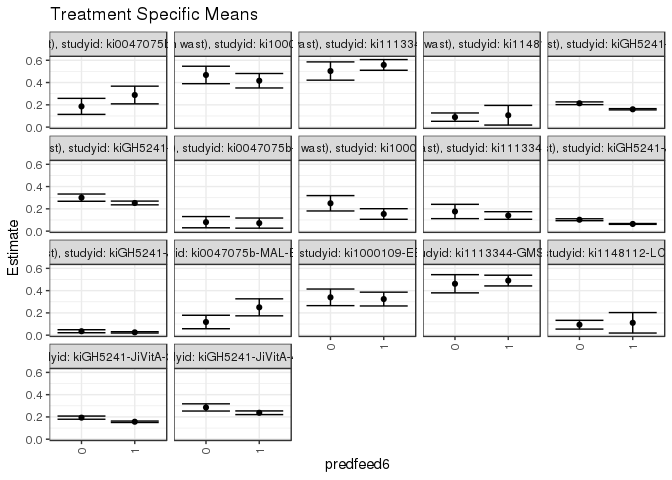

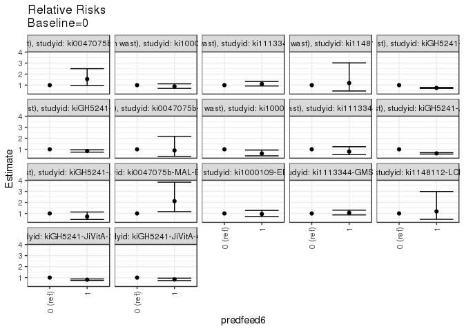

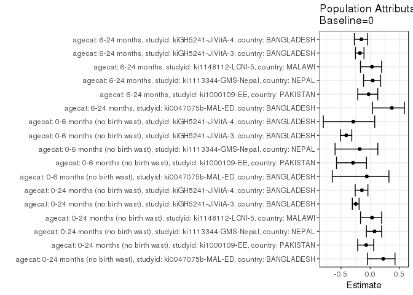

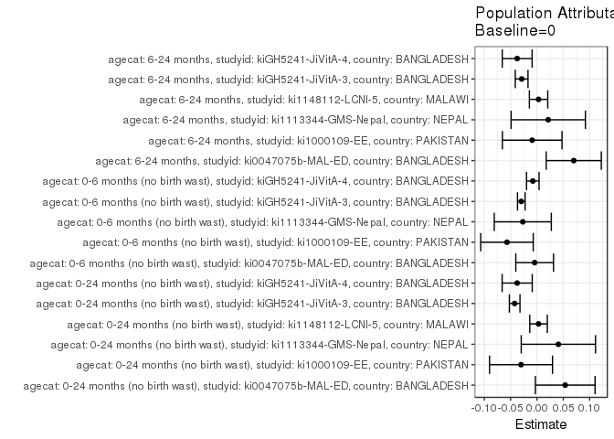

## Results Table

### Parameter: TSM

| agecat | studyid | country | intervention_level | baseline_level | estimate | ci_lower | ci_upper |
| --- | --- | --- | --- | --- | --- | --- | --- |
| 0-24 months (no birth wast) | ki0047075b-MAL-ED | BANGLADESH | 0 | NA | 0.1858407 | 0.1139706 | 0.2577108 |
| 0-24 months (no birth wast) | ki0047075b-MAL-ED | BANGLADESH | 1 | NA | 0.2880000 | 0.2084494 | 0.3675506 |
| 0-24 months (no birth wast) | ki1000109-EE | PAKISTAN | 0 | NA | 0.4679487 | 0.3895447 | 0.5463528 |
| 0-24 months (no birth wast) | ki1000109-EE | PAKISTAN | 1 | NA | 0.4162896 | 0.3512129 | 0.4813662 |
| 0-24 months (no birth wast) | ki1113344-GMS-Nepal | NEPAL | 0 | NA | 0.5034965 | 0.4214744 | 0.5855186 |
| 0-24 months (no birth wast) | ki1113344-GMS-Nepal | NEPAL | 1 | NA | 0.5582524 | 0.5102577 | 0.6062471 |
| 0-24 months (no birth wast) | ki1148112-LCNI-5 | MALAWI | 0 | NA | 0.0892857 | 0.0518739 | 0.1266975 |
| 0-24 months (no birth wast) | ki1148112-LCNI-5 | MALAWI | 1 | NA | 0.1063830 | 0.0180722 | 0.1946938 |
| 0-24 months (no birth wast) | kiGH5241-JiVitA-3 | BANGLADESH | 0 | NA | 0.2138152 | 0.2016236 | 0.2260068 |
| 0-24 months (no birth wast) | kiGH5241-JiVitA-3 | BANGLADESH | 1 | NA | 0.1598343 | 0.1542466 | 0.1654220 |
| 0-24 months (no birth wast) | kiGH5241-JiVitA-4 | BANGLADESH | 0 | NA | 0.3005952 | 0.2681959 | 0.3329946 |
| 0-24 months (no birth wast) | kiGH5241-JiVitA-4 | BANGLADESH | 1 | NA | 0.2527144 | 0.2359845 | 0.2694443 |
| 0-6 months (no birth wast) | ki0047075b-MAL-ED | BANGLADESH | 0 | NA | 0.0803571 | 0.0299051 | 0.1308092 |
| 0-6 months (no birth wast) | ki0047075b-MAL-ED | BANGLADESH | 1 | NA | 0.0720000 | 0.0265900 | 0.1174100 |
| 0-6 months (no birth wast) | ki1000109-EE | PAKISTAN | 0 | NA | 0.2500000 | 0.1810697 | 0.3189303 |
| 0-6 months (no birth wast) | ki1000109-EE | PAKISTAN | 1 | NA | 0.1538462 | 0.1062137 | 0.2014786 |
| 0-6 months (no birth wast) | ki1113344-GMS-Nepal | NEPAL | 0 | NA | 0.1764706 | 0.1123407 | 0.2406005 |
| 0-6 months (no birth wast) | ki1113344-GMS-Nepal | NEPAL | 1 | NA | 0.1403509 | 0.1062366 | 0.1744651 |
| 0-6 months (no birth wast) | kiGH5241-JiVitA-3 | BANGLADESH | 0 | NA | 0.1023055 | 0.0936424 | 0.1109685 |
| 0-6 months (no birth wast) | kiGH5241-JiVitA-3 | BANGLADESH | 1 | NA | 0.0644116 | 0.0605494 | 0.0682738 |
| 0-6 months (no birth wast) | kiGH5241-JiVitA-4 | BANGLADESH | 0 | NA | 0.0353063 | 0.0217423 | 0.0488704 |
| 0-6 months (no birth wast) | kiGH5241-JiVitA-4 | BANGLADESH | 1 | NA | 0.0252747 | 0.0194691 | 0.0310803 |
| 6-24 months | ki0047075b-MAL-ED | BANGLADESH | 0 | NA | 0.1181818 | 0.0577248 | 0.1786388 |
| 6-24 months | ki0047075b-MAL-ED | BANGLADESH | 1 | NA | 0.2500000 | 0.1736221 | 0.3263779 |
| 6-24 months | ki1000109-EE | PAKISTAN | 0 | NA | 0.3397436 | 0.2653222 | 0.4141649 |
| 6-24 months | ki1000109-EE | PAKISTAN | 1 | NA | 0.3242009 | 0.2621252 | 0.3862766 |
| 6-24 months | ki1113344-GMS-Nepal | NEPAL | 0 | NA | 0.4615385 | 0.3797576 | 0.5433193 |
| 6-24 months | ki1113344-GMS-Nepal | NEPAL | 1 | NA | 0.4903382 | 0.4421404 | 0.5385359 |
| 6-24 months | ki1148112-LCNI-5 | MALAWI | 0 | NA | 0.0938967 | 0.0546489 | 0.1331445 |
| 6-24 months | ki1148112-LCNI-5 | MALAWI | 1 | NA | 0.1111111 | 0.0191112 | 0.2031111 |
| 6-24 months | kiGH5241-JiVitA-3 | BANGLADESH | 0 | NA | 0.1935484 | 0.1793479 | 0.2077489 |
| 6-24 months | kiGH5241-JiVitA-3 | BANGLADESH | 1 | NA | 0.1567862 | 0.1502204 | 0.1633520 |
| 6-24 months | kiGH5241-JiVitA-4 | BANGLADESH | 0 | NA | 0.2852912 | 0.2530116 | 0.3175708 |
| 6-24 months | kiGH5241-JiVitA-4 | BANGLADESH | 1 | NA | 0.2374256 | 0.2208966 | 0.2539547 |

### Parameter: E(Y)

| agecat | studyid | country | intervention_level | baseline_level | estimate | ci_lower | ci_upper |
| --- | --- | --- | --- | --- | --- | --- | --- |
| 0-24 months (no birth wast) | ki0047075b-MAL-ED | BANGLADESH | NA | NA | 0.2394958 | 0.1851615 | 0.2938300 |
| 0-24 months (no birth wast) | ki1000109-EE | PAKISTAN | NA | NA | 0.4376658 | 0.3875213 | 0.4878102 |
| 0-24 months (no birth wast) | ki1113344-GMS-Nepal | NEPAL | NA | NA | 0.5441441 | 0.5026713 | 0.5856170 |
| 0-24 months (no birth wast) | ki1148112-LCNI-5 | MALAWI | NA | NA | 0.0922509 | 0.0577338 | 0.1267680 |
| 0-24 months (no birth wast) | kiGH5241-JiVitA-3 | BANGLADESH | NA | NA | 0.1714373 | 0.1660817 | 0.1767929 |
| 0-24 months (no birth wast) | kiGH5241-JiVitA-4 | BANGLADESH | NA | NA | 0.2630009 | 0.2480666 | 0.2779351 |
| 0-6 months (no birth wast) | ki0047075b-MAL-ED | BANGLADESH | NA | NA | 0.0759494 | 0.0421505 | 0.1097482 |
| 0-6 months (no birth wast) | ki1000109-EE | PAKISTAN | NA | NA | 0.1930295 | 0.1529228 | 0.2331362 |
| 0-6 months (no birth wast) | ki1113344-GMS-Nepal | NEPAL | NA | NA | 0.1495327 | 0.1192863 | 0.1797792 |
| 0-6 months (no birth wast) | kiGH5241-JiVitA-3 | BANGLADESH | NA | NA | 0.0725281 | 0.0688266 | 0.0762296 |
| 0-6 months (no birth wast) | kiGH5241-JiVitA-4 | BANGLADESH | NA | NA | 0.0273735 | 0.0221056 | 0.0326413 |
| 6-24 months | ki0047075b-MAL-ED | BANGLADESH | NA | NA | 0.1880342 | 0.1378627 | 0.2382057 |
| 6-24 months | ki1000109-EE | PAKISTAN | NA | NA | 0.3306667 | 0.2829875 | 0.3783458 |
| 6-24 months | ki1113344-GMS-Nepal | NEPAL | NA | NA | 0.4829443 | 0.4414080 | 0.5244807 |
| 6-24 months | ki1148112-LCNI-5 | MALAWI | NA | NA | 0.0968992 | 0.0607324 | 0.1330660 |
| 6-24 months | kiGH5241-JiVitA-3 | BANGLADESH | NA | NA | 0.1644307 | 0.1582894 | 0.1705720 |
| 6-24 months | kiGH5241-JiVitA-4 | BANGLADESH | NA | NA | 0.2477181 | 0.2329462 | 0.2624900 |

### Parameter: RR

| agecat | studyid | country | intervention_level | baseline_level | estimate | ci_lower | ci_upper |
| --- | --- | --- | --- | --- | --- | --- | --- |
| 0-24 months (no birth wast) | ki0047075b-MAL-ED | BANGLADESH | 0 | 0 | 1.0000000 | 1.0000000 | 1.0000000 |
| 0-24 months (no birth wast) | ki0047075b-MAL-ED | BANGLADESH | 1 | 0 | 1.5497143 | 0.9635100 | 2.4925682 |
| 0-24 months (no birth wast) | ki1000109-EE | PAKISTAN | 0 | 0 | 1.0000000 | 1.0000000 | 1.0000000 |
| 0-24 months (no birth wast) | ki1000109-EE | PAKISTAN | 1 | 0 | 0.8896052 | 0.7074217 | 1.1187067 |
| 0-24 months (no birth wast) | ki1113344-GMS-Nepal | NEPAL | 0 | 0 | 1.0000000 | 1.0000000 | 1.0000000 |
| 0-24 months (no birth wast) | ki1113344-GMS-Nepal | NEPAL | 1 | 0 | 1.1087513 | 0.9222260 | 1.3330025 |
| 0-24 months (no birth wast) | ki1148112-LCNI-5 | MALAWI | 0 | 0 | 1.0000000 | 1.0000000 | 1.0000000 |
| 0-24 months (no birth wast) | ki1148112-LCNI-5 | MALAWI | 1 | 0 | 1.1914894 | 0.4701640 | 3.0194719 |
| 0-24 months (no birth wast) | kiGH5241-JiVitA-3 | BANGLADESH | 0 | 0 | 1.0000000 | 1.0000000 | 1.0000000 |
| 0-24 months (no birth wast) | kiGH5241-JiVitA-3 | BANGLADESH | 1 | 0 | 0.7475346 | 0.7016995 | 0.7963637 |
| 0-24 months (no birth wast) | kiGH5241-JiVitA-4 | BANGLADESH | 0 | 0 | 1.0000000 | 1.0000000 | 1.0000000 |
| 0-24 months (no birth wast) | kiGH5241-JiVitA-4 | BANGLADESH | 1 | 0 | 0.8407134 | 0.7410883 | 0.9537312 |
| 0-6 months (no birth wast) | ki0047075b-MAL-ED | BANGLADESH | 0 | 0 | 1.0000000 | 1.0000000 | 1.0000000 |
| 0-6 months (no birth wast) | ki0047075b-MAL-ED | BANGLADESH | 1 | 0 | 0.8960000 | 0.3679747 | 2.1817153 |
| 0-6 months (no birth wast) | ki1000109-EE | PAKISTAN | 0 | 0 | 1.0000000 | 1.0000000 | 1.0000000 |
| 0-6 months (no birth wast) | ki1000109-EE | PAKISTAN | 1 | 0 | 0.6153846 | 0.4065318 | 0.9315341 |
| 0-6 months (no birth wast) | ki1113344-GMS-Nepal | NEPAL | 0 | 0 | 1.0000000 | 1.0000000 | 1.0000000 |
| 0-6 months (no birth wast) | ki1113344-GMS-Nepal | NEPAL | 1 | 0 | 0.7953216 | 0.5136535 | 1.2314459 |
| 0-6 months (no birth wast) | kiGH5241-JiVitA-3 | BANGLADESH | 0 | 0 | 1.0000000 | 1.0000000 | 1.0000000 |
| 0-6 months (no birth wast) | kiGH5241-JiVitA-3 | BANGLADESH | 1 | 0 | 0.6296008 | 0.5702588 | 0.6951180 |
| 0-6 months (no birth wast) | kiGH5241-JiVitA-4 | BANGLADESH | 0 | 0 | 1.0000000 | 1.0000000 | 1.0000000 |
| 0-6 months (no birth wast) | kiGH5241-JiVitA-4 | BANGLADESH | 1 | 0 | 0.7158694 | 0.4523129 | 1.1329966 |
| 6-24 months | ki0047075b-MAL-ED | BANGLADESH | 0 | 0 | 1.0000000 | 1.0000000 | 1.0000000 |
| 6-24 months | ki0047075b-MAL-ED | BANGLADESH | 1 | 0 | 2.1153846 | 1.1657825 | 3.8384966 |
| 6-24 months | ki1000109-EE | PAKISTAN | 0 | 0 | 1.0000000 | 1.0000000 | 1.0000000 |
| 6-24 months | ki1000109-EE | PAKISTAN | 1 | 0 | 0.9542517 | 0.7133617 | 1.2764863 |
| 6-24 months | ki1113344-GMS-Nepal | NEPAL | 0 | 0 | 1.0000000 | 1.0000000 | 1.0000000 |
| 6-24 months | ki1113344-GMS-Nepal | NEPAL | 1 | 0 | 1.0623994 | 0.8675346 | 1.3010345 |
| 6-24 months | ki1148112-LCNI-5 | MALAWI | 0 | 0 | 1.0000000 | 1.0000000 | 1.0000000 |
| 6-24 months | ki1148112-LCNI-5 | MALAWI | 1 | 0 | 1.1833333 | 0.4680466 | 2.9917487 |
| 6-24 months | kiGH5241-JiVitA-3 | BANGLADESH | 0 | 0 | 1.0000000 | 1.0000000 | 1.0000000 |
| 6-24 months | kiGH5241-JiVitA-3 | BANGLADESH | 1 | 0 | 0.8100621 | 0.7461372 | 0.8794638 |
| 6-24 months | kiGH5241-JiVitA-4 | BANGLADESH | 0 | 0 | 1.0000000 | 1.0000000 | 1.0000000 |
| 6-24 months | kiGH5241-JiVitA-4 | BANGLADESH | 1 | 0 | 0.8322220 | 0.7291220 | 0.9499007 |

### Parameter: PAR

| agecat | studyid | country | intervention_level | baseline_level | estimate | ci_lower | ci_upper |
| --- | --- | --- | --- | --- | --- | --- | --- |
| 0-24 months (no birth wast) | ki0047075b-MAL-ED | BANGLADESH | 0 | NA | 0.0536551 | -0.0030251 | 0.1103353 |
| 0-24 months (no birth wast) | ki1000109-EE | PAKISTAN | 0 | NA | -0.0302829 | -0.0900686 | 0.0295027 |
| 0-24 months (no birth wast) | ki1113344-GMS-Nepal | NEPAL | 0 | NA | 0.0406476 | -0.0299270 | 0.1112223 |
| 0-24 months (no birth wast) | ki1148112-LCNI-5 | MALAWI | 0 | NA | 0.0029652 | -0.0136863 | 0.0196167 |
| 0-24 months (no birth wast) | kiGH5241-JiVitA-3 | BANGLADESH | 0 | NA | -0.0423779 | -0.0524590 | -0.0322968 |
| 0-24 months (no birth wast) | kiGH5241-JiVitA-4 | BANGLADESH | 0 | NA | -0.0375944 | -0.0661535 | -0.0090352 |
| 0-6 months (no birth wast) | ki0047075b-MAL-ED | BANGLADESH | 0 | NA | -0.0044078 | -0.0402126 | 0.0313970 |
| 0-6 months (no birth wast) | ki1000109-EE | PAKISTAN | 0 | NA | -0.0569705 | -0.1068453 | -0.0070958 |
| 0-6 months (no birth wast) | ki1113344-GMS-Nepal | NEPAL | 0 | NA | -0.0269379 | -0.0811281 | 0.0272523 |
| 0-6 months (no birth wast) | kiGH5241-JiVitA-3 | BANGLADESH | 0 | NA | -0.0297774 | -0.0369942 | -0.0225606 |
| 0-6 months (no birth wast) | kiGH5241-JiVitA-4 | BANGLADESH | 0 | NA | -0.0079329 | -0.0198501 | 0.0039843 |
| 6-24 months | ki0047075b-MAL-ED | BANGLADESH | 0 | NA | 0.0698524 | 0.0175469 | 0.1221578 |
| 6-24 months | ki1000109-EE | PAKISTAN | 0 | NA | -0.0090769 | -0.0656788 | 0.0475250 |
| 6-24 months | ki1113344-GMS-Nepal | NEPAL | 0 | NA | 0.0214059 | -0.0491580 | 0.0919698 |
| 6-24 months | ki1148112-LCNI-5 | MALAWI | 0 | NA | 0.0030025 | -0.0144614 | 0.0204665 |
| 6-24 months | kiGH5241-JiVitA-3 | BANGLADESH | 0 | NA | -0.0291177 | -0.0412049 | -0.0170305 |
| 6-24 months | kiGH5241-JiVitA-4 | BANGLADESH | 0 | NA | -0.0375731 | -0.0659351 | -0.0092111 |

### Parameter: PAF

| agecat | studyid | country | intervention_level | baseline_level | estimate | ci_lower | ci_upper |
| --- | --- | --- | --- | --- | --- | --- | --- |
| 0-24 months (no birth wast) | ki0047075b-MAL-ED | BANGLADESH | 0 | NA | 0.2240335 | -0.0488875 | 0.4259404 |
| 0-24 months (no birth wast) | ki1000109-EE | PAKISTAN | 0 | NA | -0.0691919 | -0.2150766 | 0.0591775 |
| 0-24 months (no birth wast) | ki1113344-GMS-Nepal | NEPAL | 0 | NA | 0.0747001 | -0.0647019 | 0.1958501 |
| 0-24 months (no birth wast) | ki1148112-LCNI-5 | MALAWI | 0 | NA | 0.0321429 | -0.1658997 | 0.1965454 |
| 0-24 months (no birth wast) | kiGH5241-JiVitA-3 | BANGLADESH | 0 | NA | -0.2471917 | -0.3065555 | -0.1905252 |
| 0-24 months (no birth wast) | kiGH5241-JiVitA-4 | BANGLADESH | 0 | NA | -0.1429440 | -0.2570770 | -0.0391733 |
| 0-6 months (no birth wast) | ki0047075b-MAL-ED | BANGLADESH | 0 | NA | -0.0580357 | -0.6510846 | 0.3219975 |
| 0-6 months (no birth wast) | ki1000109-EE | PAKISTAN | 0 | NA | -0.2951389 | -0.5776999 | -0.0631836 |
| 0-6 months (no birth wast) | ki1113344-GMS-Nepal | NEPAL | 0 | NA | -0.1801471 | -0.6028886 | 0.1311018 |
| 0-6 months (no birth wast) | kiGH5241-JiVitA-3 | BANGLADESH | 0 | NA | -0.4105640 | -0.5121184 | -0.3158299 |
| 0-6 months (no birth wast) | kiGH5241-JiVitA-4 | BANGLADESH | 0 | NA | -0.2898020 | -0.8037982 | 0.0777298 |
| 6-24 months | ki0047075b-MAL-ED | BANGLADESH | 0 | NA | 0.3714876 | 0.0413250 | 0.5879440 |
| 6-24 months | ki1000109-EE | PAKISTAN | 0 | NA | -0.0274504 | -0.2137114 | 0.1302263 |
| 6-24 months | ki1113344-GMS-Nepal | NEPAL | 0 | NA | 0.0443237 | -0.1135947 | 0.1798478 |
| 6-24 months | ki1148112-LCNI-5 | MALAWI | 0 | NA | 0.0309859 | -0.1667375 | 0.1952018 |
| 6-24 months | kiGH5241-JiVitA-3 | BANGLADESH | 0 | NA | -0.1770818 | -0.2524041 | -0.1062895 |
| 6-24 months | kiGH5241-JiVitA-4 | BANGLADESH | 0 | NA | -0.1516769 | -0.2722183 | -0.0425566 |